# Data Viz Project

J. Voltz

12/23/2021

## Load Packages

```r
library(tidyverse)
library(ggrepel)
```

```r
library(tidyr)
library(cowplot)
library(GGally)
library(scales)
```

## Problem 1

- Load in the data_fastfood_sales.csv file into R.
- Create a scatter plot with column `us_sales` along the x-axis and the column `unit_count` along the y-axis.
- Each axis should be transformed to a `log10` scale and should be appropriately labeled.
- Color each point by the proportion of franchised stores (i.e. `num_franchised_stores` divided by `unit_count`).
- Label each point with the name of the fast food restaurant using the `ggrepel` package.
- Use the classic dark-on-light ggplot2 theme.
- Rename the legend appropriately.

```r
df <- read_csv('data_fastfood_sales.csv')
glimpse(df)
```

```
## Rows: 19
## Columns: 6
## $ restaurant            <chr> "Subway", "Mcdonalds", "Starbucks", "Dunkin Donu~
## $ average_sales         <dbl> 416.86, 2670.32, 945.27, 733.13, 900.00, 1387.81~
## $ us_sales              <dbl> 10800.00, 37480.67, 13167.61, 9192.00, 5510.84, ~
## $ num_company_stores    <dbl> 0, 842, 8222, 0, 96, 50, 647, 337, 392, 535, 54,~
## $ num_franchised_stores <dbl> 25908, 13194, 5708, 12538, 7426, 7196, 5799, 543~
## $ unit_count            <dbl> 25908, 14036, 13930, 12538, 7522, 7266, 6446, 57~
```

```r
summary(df)
```

```
##   restaurant        average_sales       us_sales     num_company_stores
##  Length:19          Min.   : 360.7   Min.   :  606   Min.   :   0.0
##  Class :character   1st Qu.: 857.5   1st Qu.: 3500   1st Qu.:  53.5
##  Mode  :character   Median :1130.0   Median : 4476   Median : 276.0
##                     Mean   :1189.9   Mean   : 7593   Mean   : 839.0
##                     3rd Qu.:1470.1   3rd Qu.: 9539   3rd Qu.: 677.5
##                     Max.   :2670.3   Max.   :37481   Max.   :8222.0
##  num_franchised_stores   unit_count
##  Min.   :    0         Min.   : 2231
##  1st Qu.: 2583         1st Qu.: 3034
##  Median : 4055         Median : 4332
##  Mean   : 5999         Mean   : 6838
##  3rd Qu.: 6498         3rd Qu.: 7394
##  Max.   :25908         Max.   :25908
```

```r
df <- df %>%
          mutate(prop_stores = num_franchised_stores/unit_count)

head(df)
```

```
## # A tibble: 6 x 7
##   restaurant average_sales us_sales num_company_sto~ num_franchised_~ unit_count
##   <chr>              <dbl>    <dbl>            <dbl>            <dbl>      <dbl>
## 1 Subway              417.   10800                 0            25908      25908
## 2 Mcdonalds          2670.   37481.              842            13194      14036
## 3 Starbucks           945.   13168.             8222             5708      13930
## 4 Dunkin Do~          733.    9192                 0            12538      12538
## 5 Pizza Hut           900     5511.               96             7426       7522
## 6 Burger Ki~         1388.   10028.               50             7196       7266
## # ... with 1 more variable: prop_stores <dbl>
```

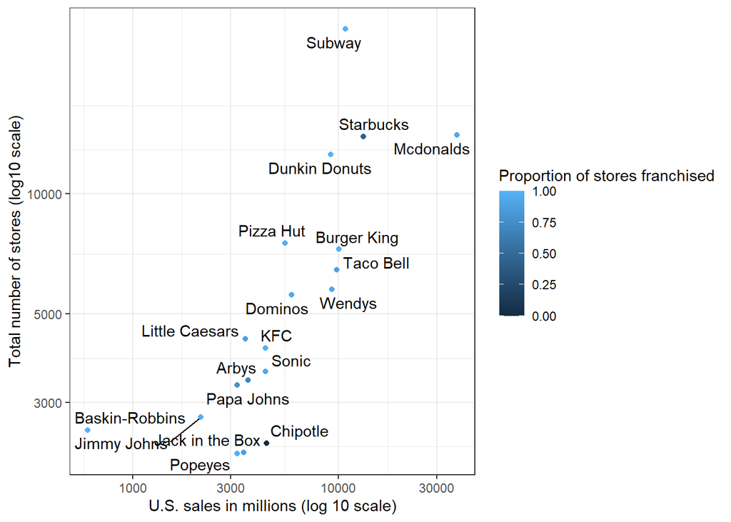

```r
ggplot(df, aes(x = us_sales, y = unit_count, label = restaurant)) +
  geom_text_repel() +
  scale_x_continuous(trans = "log10") +
  scale_y_continuous(trans = 'log10') +
  geom_point(aes(color = prop_stores)) +
  labs(x = 'U.S. sales in millions (log 10 scale)', y = 'Total number of stores (log10 scale)', color = 'Proportion of stores franchised') +

  theme_bw()
```

```r
#guides(col=guide_legend('Proportion of stores franchised'))+
```

## Problem 2

- Load in the data_fastfood_sales.csv file into R.
- Create a bar plot with the `average_sales` on the x-axis and `restaurant` on the y-axis (Hint: consider using the `coord_flip()` function).
- The order of restaurants on the y-axis should be in decreasing order of average sales with the restaurant with the largest average sales at the top and the restaurant with the smallest average sales at the bottom.
- Add text to each bar on the plot with the average sales (in the thousands) for each restaurant.
- Each axis should be appropriately labeled.
- Along the x-axis, transform the text labels to include a dollar sign in front of each number.
- Use the classic ggplot2 theme.

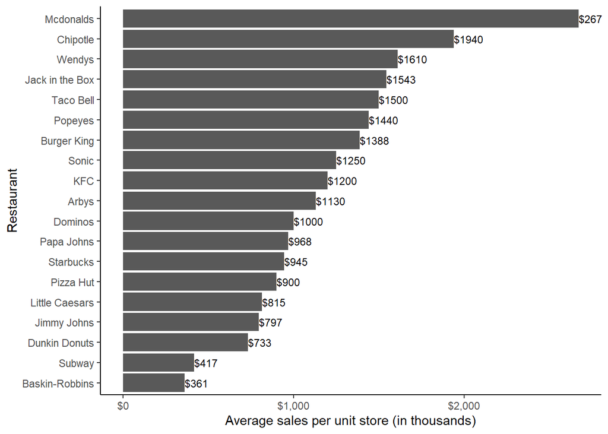

```r
df %>%
   arrange(average_sales) %>%
  mutate(restaurant=factor(restaurant, levels=restaurant)) %>%
  ggplot(aes(x = restaurant, y = average_sales)) +
  geom_bar(stat = "identity") +
  geom_text(aes(label = paste('$',round(average_sales,0), sep =""),hjust = 0), size = 3) +
   coord_flip() +
 theme_classic() +
  labs(y = 'Average sales per unit store (in thousands)', x = 'Restaurant') +
 scale_y_continuous(labels = label_dollar())
```

## Problem 3

- Load in the data_fastfood_calories.csv file into R.
- Create a scatter plot with the column `calories` along the x-axis and the column `sodium` along the y-axis.
- Each restaurant should have its own scatter plot (Hint: consider the facet functions).
- Add a horizontal line at y=2300 in each scatter plot.
- Each axis of the scatter plot should have an appropriately labeled x-axis and y-axis.
- For all food items with a sodium level of greater than 2300 (mg) (the maximum daily intake from the Centers for Disease Control), add a text label each point with the name of the entree food item using the `ggrepel` package.
- Use the classic dark-on-light ggplot2 theme.
- Rename the legend.

```r
df2 <- read_csv('data_fastfood_calories.csv')
glimpse(df2)
```

```
## Rows: 515
## Columns: 16
## $ restaurant  <chr> "Mcdonalds", "Mcdonalds", "Mcdonalds", "Mcdonalds", "Mcdon~
## $ item        <chr> "Artisan Grilled Chicken Sandwich", "Single Bacon Smokehou~
## $ calories    <dbl> 380, 840, 1130, 750, 920, 540, 300, 510, 430, 770, 380, 62~
## $ cal_fat     <dbl> 60, 410, 600, 280, 410, 250, 100, 210, 190, 400, 170, 300,~
## $ total_fat   <dbl> 7, 45, 67, 31, 45, 28, 12, 24, 21, 45, 18, 34, 20, 34, 8, ~
## $ sat_fat     <dbl> 2.0, 17.0, 27.0, 10.0, 12.0, 10.0, 5.0, 4.0, 11.0, 21.0, 4~
## $ trans_fat   <dbl> 0.0, 1.5, 3.0, 0.5, 0.5, 1.0, 0.5, 0.0, 1.0, 2.5, 0.0, 1.5~
## $ cholesterol <dbl> 95, 130, 220, 155, 120, 80, 40, 65, 85, 175, 40, 95, 125, ~
## $ sodium      <dbl> 1110, 1580, 1920, 1940, 1980, 950, 680, 1040, 1040, 1290, ~
## $ total_carb  <dbl> 44, 62, 63, 62, 81, 46, 33, 49, 35, 42, 38, 48, 48, 67, 31~
## $ fiber       <dbl> 3, 2, 3, 2, 4, 3, 2, 3, 2, 3, 2, 3, 3, 5, 2, 2, 3, 3, 5, 2~
## $ sugar       <dbl> 11, 18, 18, 18, 18, 9, 7, 6, 7, 10, 5, 11, 11, 11, 6, 3, 1~
## $ protein     <dbl> 37, 46, 70, 55, 46, 25, 15, 25, 25, 51, 15, 32, 42, 33, 13~
## $ vit_a       <dbl> 4, 6, 10, 6, 6, 10, 10, 0, 20, 20, 2, 10, 10, 10, 2, 4, 6,~
## $ vit_c       <dbl> 20, 20, 20, 25, 20, 2, 2, 4, 4, 6, 0, 10, 20, 15, 2, 6, 15~
## $ calcium     <dbl> 20, 20, 50, 20, 20, 15, 10, 2, 15, 20, 15, 35, 35, 35, 4, ~
```

```r
summary(df2)
```

```
##   restaurant            item              calories         cal_fat
##  Length:515         Length:515         Min.   :  20.0   Min.   :   0.0
##  Class :character   Class :character   1st Qu.: 330.0   1st Qu.: 120.0
##  Mode  :character   Mode  :character   Median : 490.0   Median : 210.0
##                                        Mean   : 530.9   Mean   : 238.8
##                                        3rd Qu.: 690.0   3rd Qu.: 310.0
##                                        Max.   :2430.0   Max.   :1270.0
##
##    total_fat         sat_fat         trans_fat      cholesterol
##  Min.   :  0.00   Min.   : 0.000   Min.   :0.000   Min.   :  0.00
##  1st Qu.: 14.00   1st Qu.: 4.000   1st Qu.:0.000   1st Qu.: 35.00
##  Median : 23.00   Median : 7.000   Median :0.000   Median : 60.00
##  Mean   : 26.59   Mean   : 8.153   Mean   :0.465   Mean   : 72.46
##  3rd Qu.: 35.00   3rd Qu.:11.000   3rd Qu.:1.000   3rd Qu.: 95.00
##  Max.   :141.00   Max.   :47.000   Max.   :8.000   Max.   :805.00
##
##      sodium       total_carb         fiber            sugar
##  Min.   :  15   Min.   :  0.00   Min.   : 0.000   Min.   : 0.000
##  1st Qu.: 800   1st Qu.: 28.50   1st Qu.: 2.000   1st Qu.: 3.000
##  Median :1110   Median : 44.00   Median : 3.000   Median : 6.000
##  Mean   :1247   Mean   : 45.66   Mean   : 4.137   Mean   : 7.262
##  3rd Qu.:1550   3rd Qu.: 57.00   3rd Qu.: 5.000   3rd Qu.: 9.000
##  Max.   :6080   Max.   :156.00   Max.   :17.000   Max.   :87.000
##                                  NA's   :12
##     protein           vit_a            vit_c           calcium
##  Min.   :  1.00   Min.   :  0.00   Min.   :  0.00   Min.   :  0.00
##  1st Qu.: 16.00   1st Qu.:  4.00   1st Qu.:  4.00   1st Qu.:  8.00
##  Median : 24.50   Median : 10.00   Median : 10.00   Median : 20.00
##  Mean   : 27.89   Mean   : 18.86   Mean   : 20.17   Mean   : 24.85
##  3rd Qu.: 36.00   3rd Qu.: 20.00   3rd Qu.: 30.00   3rd Qu.: 30.00
##  Max.   :186.00   Max.   :180.00   Max.   :400.00   Max.   :290.00
##  NA's   :1        NA's   :214      NA's   :210      NA's   :210
```

```r
unique(df2$restaurant)
```

```
## [1] "Mcdonalds"   "Chick Fil-A" "Sonic"       "Arbys"       "Burger King"
## [6] "Dairy Queen" "Subway"      "Taco Bell"
```

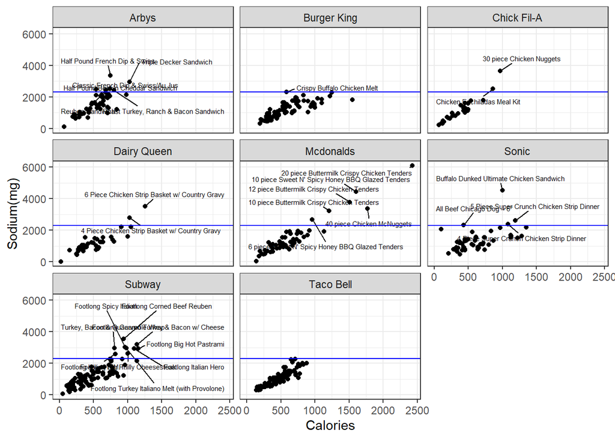

```r
df_sod <- df2 %>%
  filter(sodium > 2300)

ggplot(df2, aes(x = calories, y = sodium)) +

  geom_point()+
   geom_text_repel(data = df_sod, aes(x = calories, y = sodium, label = item), size = 2,min.segment.length = 0, box.padding = 0.5, max.overlaps = Inf, nudge_y = 1,
                  hjust = 0.5,
                  direction = "both"
                 ) +
   geom_hline(yintercept=2300, color = 'blue') +

  facet_wrap(~restaurant)+

  theme_bw() +
  labs(y = 'Sodium(mg)', x = 'Calories')
```

## Problem 4

- Load in the data_fastfood_calories.csv file into R.
- Create a new column titled `is_salad` that contains a `TRUE` or `FALSE` value of whether or not the name of entree food item contains the character string “salad” in it.
- Create boxplots with `calories` on the x-axis and `restaurant` on the y-axis.
- The order of restaurants on the y-axis should be in decreasing order of calories with the restaurant with the median calories at the top and the restaurant with the smallest median calories at the bottom.
- Hide any outliers in the boxplots.
- On top of the boxplots add a set of jittered points representing each food item.
- Each point should be colored based on whether it is an item with the word “salad” in it or not.
- Each axis should be appropriately labeled, the legend should be appropriately labeled, and the x-axis should be transformed to a log10 scale.
- Use the classic dark-on-light ggplot2 theme.

```r
df_salad <- df2 %>%
 mutate(is_salad = ifelse(grepl('Salad', item),TRUE,  FALSE)) %>%
  group_by(restaurant) %>%
  mutate(med_cal = median(calories))
```

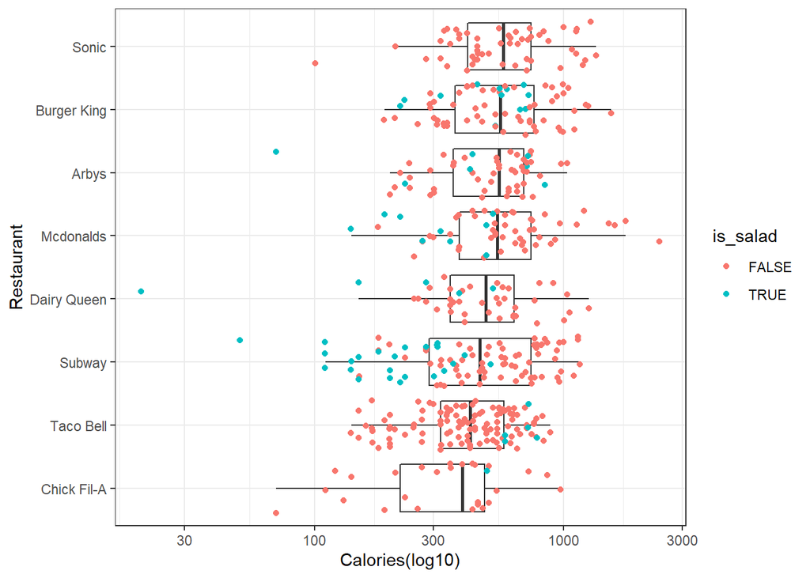

```r
ggplot(df_salad, aes(x = calories, y = reorder(restaurant, calories, FUN = median))) +
  geom_boxplot(outlier.shape = NA) +
  geom_jitter(aes(color = is_salad)) +
  scale_x_continuous(trans = "log10") +
  labs(x = 'Calories(log10)', y = 'Restaurant') +
  theme_bw()
```

## Problem 5

- Using the data_fastfood_calories.csv, remove rows that contain the Taco Bell restaurant
- For each restaurant calculate the median amount of sugar in each entree item.
- Using this summarized dataset, combine this summarized dataset with the data_fastfood_sales.csv dataset. The combined dataset should only include restaurants that are included in both datasets.
- Using this new dataset, create a bar plot with `restaurant` on the x-axis and on the `us_sales` y-axis.
- The order of restaurants on the x-axis should be in increasing order of US sales with the restaurant with the largest average sales on the right and the restaurant with the smallest US sales on the left.
- Color the bars by the median amount of sugar in the entree items from that restaurant.
- Each axis should be appropriately labeled.
- Use the classic ggplot2 theme.

```r
cal <- df2 %>%
        subset(!restaurant == 'Taco Bell') %>%
  group_by(restaurant) %>%
  mutate(med_sug = median(sugar))

combo <- inner_join(df,cal,"restaurant") %>%
  mutate(us_sales = us_sales/100)
```

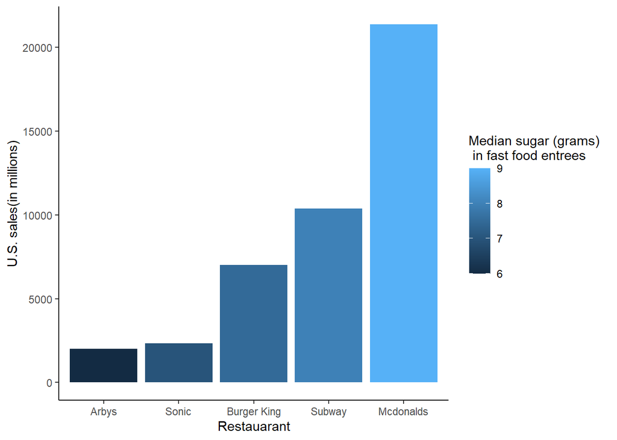

```r
combo %>%
ggplot(aes(reorder(x = restaurant, us_sales), y = us_sales,fill = med_sug)) +
  geom_bar(stat = 'identity') +
  labs(x = 'Restauarant', y = 'U.S. sales(in millions)', fill = 'Median sugar (grams) \n in fast food entrees') +
  theme_classic()
```